# Práctica 1 - Series temporales

Eduardo Salgado Díaz del Río

7 de Noviembre de 2022

## Objetivo de la práctica

El objetivo de la práctica a realizar es la utilización del dataset de los ingresos de Apple mediante una serie temporal en la búsqueda de poder realizar una predicción. Para ello, se debera cual de los dos mejores modelos de ETS y ARIMA para estimar cúal es el mejor modelo a implementar.

## Cargamos las librerías

```python
import pandas as pd
import numpy as np
import seaborn as sns
import statsmodels.api as sm
from matplotlib import pyplot as plt
from sktime.utils.plotting import plot_series
from datetime import datetime
from sktime.transformations.series.boxcox import LogTransformer
from sktime.forecasting.ets import AutoETS
from sktime.performance_metrics.forecasting import mean_absolute_percentage_error
from sktime.performance_metrics.forecasting import MeanSquaredError
from sktime.forecasting.exp_smoothing import ExponentialSmoothing
from sktime.transformations.series.boxcox import LogTransformer
from sktime.forecasting.base import ForecastingHorizon
from sktime.forecasting.model_selection import temporal_train_test_split
from sktime.forecasting.arima import AutoARIMA
from sktime.performance_metrics.forecasting import mean_absolute_percentage_error
from sktime.performance_metrics.forecasting import MeanSquaredError
from sktime.utils.plotting import plot_correlations
from sktime.transformations.series.difference import Differencer
import warnings
warnings.filterwarnings('ignore')
```

## Carga de los datos, tratamiento y limpieza

```python
df_AAPL = (pd.read_csv("/Users/eduardo/Documents/CUNEF_ASIGNATURAS/SERIES_TEMPORALES/Trabajo_HW/data/raw/aapl_ok.csv",sep=';')
           .assign(**{'fecha': lambda df: pd.to_datetime(df['fecha'])})
           .assign(**{'Ingresos': lambda df: df['Ingresos'].str.replace(',', '.').astype(float)}))
```

```python
pd.isnull(df_AAPL[[x for x in df_AAPL.columns[pd.isna(df_AAPL).any()].tolist()]]).sum()
```

```
Series([], dtype: float64)
```

```python
df_AAPL['Trimeste'] = pd.PeriodIndex(df_AAPL.fecha, freq='Q')
df_AAPL = df_AAPL.set_index('Trimeste')

#creamos un nuevo data frame con los trimestres como indices e ingresos como datos, por tanto eliminamos la fehca
df_AAPL= df_AAPL.drop('fecha', axis=1)
df_AAPL.head()
```

| Trimeste | Ingresos |
| --- | --- |
| 1989Q4 | 1493.4 |
| 1990Q1 | 1346.2 |
| 1990Q2 | 1364.8 |
| 1990Q3 | 1354.1 |
| 1990Q4 | 1675.5 |

Representamos la gráfica de los ingresos por cuatrimestre de la empresa APPLE.

```python
transformer = LogTransformer()
log_AAPL= transformer.fit_transform(df_AAPL)
log_AAPL.tail()
```

| Trimeste | Ingresos |
| --- | --- |
| 2020Q2 | 10.996836 |
| 2020Q3 | 11.077486 |
| 2020Q4 | 11.621233 |
| 2021Q1 | 11.402932 |
| 2021Q2 | 11.307548 |

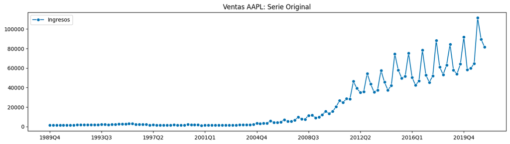

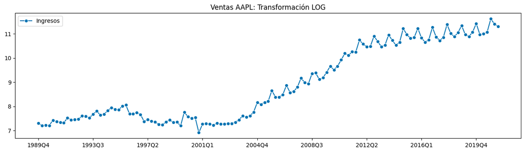

```python
# Cargamos las gráfica de la serie temporal original y su transformación en logaritmo.
fig, ax =plot_series(df_AAPL, labels=["Ingresos"])
ax.set_title('Ventas AAPL: Serie Original')
fig, ax =plot_series(log_AAPL, labels=["Ingresos"])
ax.set_title('Ventas AAPL: Transformación LOG')
```

## Análisis estacional de los cuatrimestres.

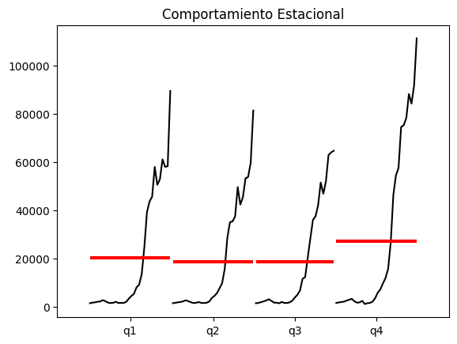

```python
ax = plt.gca()
sm.graphics.tsa.quarter_plot(df_AAPL['Ingresos'],ax=ax)
ax.set_title('Comportamiento Estacional')
```

# Modelo ETS

## Dividimos entre train y test

Como nos comenta el problema a resolver separamos entre train y test desde los ultimos ocho trimestres, es decir, los dos ultimos años del dataset

```
119 8
```

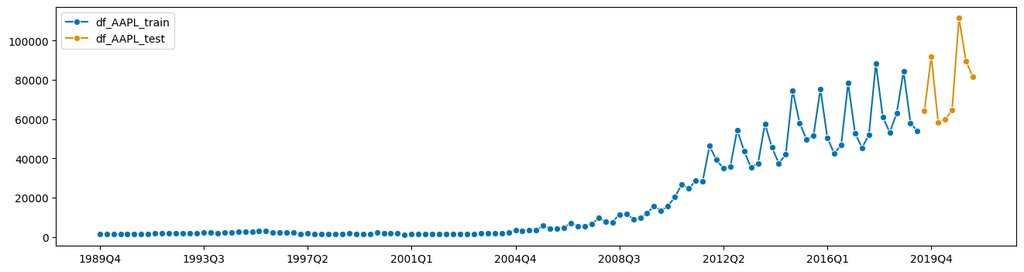

```python
df_AAPL_train, df_AAPL_test = temporal_train_test_split(y = df_AAPL['Ingresos'].astype('float64'), test_size=8)
plot_series(df_AAPL_train, df_AAPL_test, labels=["df_AAPL_train", "df_AAPL_test"])
print(df_AAPL_train.shape[0], df_AAPL_test.shape[0])
```

```python
# longitud de la predicción
fh = np.arange(1, 9)
```

## ETS automático

```python
AAPL_auto_model = AutoETS(auto=True, sp=4, n_jobs=-1)
```

### Entrenamiento

```python
AAPL_auto_model.fit(df_AAPL_train)
```

```
AutoETS(auto=True, n_jobs=-1, sp=4)
```

```python
# es un modelo MAM error multiplicativo tendecia lineal aditiva y summary
print(AAPL_auto_model.summary())
```

```
                                 ETS Results
==============================================================================
Dep. Variable:                      y   No. Observations:                  119
Model:                       ETS(MAM)   Log Likelihood                -968.025
Date:                Mon, 07 Nov 2022   AIC                           1956.050
Time:                        13:51:43   BIC                           1983.841
Sample:                    12-31-1989   HQIC                          1967.335
                         - 06-30-2019   Scale                            0.018
Covariance Type:               approx
======================================================================================
                         coef    std err          z      P>|z|      [0.025      0.975]
--------------------------------------------------------------------------------------
smoothing_level        0.4225      0.055      7.739      0.000       0.316       0.530
smoothing_trend        0.1685      0.034      4.890      0.000       0.101       0.236
smoothing_seasonal     0.3568      0.077      4.646      0.000       0.206       0.507
initial_level       1370.9326    598.926      2.289      0.022     197.059    2544.806
initial_trend         46.0330     96.115      0.479      0.632    -142.349     234.415
initial_seasonal.0     0.8649      0.393      2.199      0.028       0.094       1.636
initial_seasonal.1     0.8891      0.402      2.210      0.027       0.101       1.678
initial_seasonal.2     0.9181      0.414      2.216      0.027       0.106       1.730
initial_seasonal.3     1.0000      0.441      2.265      0.024       0.135       1.865
===================================================================================
Ljung-Box (Q):                        5.15   Jarque-Bera (JB):               112.84
Prob(Q):                              0.74   Prob(JB):                         0.00
Heteroskedasticity (H):               1.20   Skew:                            -0.39
Prob(H) (two-sided):                  0.57   Kurtosis:                         7.71
===================================================================================

Warnings:
[1] Covariance matrix calculated using numerical (complex-step) differentiation.
```

### Predicción del modelo MAM

```python
AAPL_pred = AAPL_auto_model.predict(fh)
AAPL_pred
```

```
2019Q3    58581.327662
2019Q4    85963.041124
2020Q1    59751.799099
2020Q2    53079.526755
2020Q3    58323.467092
2020Q4    85584.236148
2021Q1    59488.206268
2021Q2    52845.109874
Freq: Q-DEC, dtype: float64
```

### Intervalos de confianza

```python
AAPL_pred_ints = AAPL_auto_model.predict_interval(fh, coverage=0.9)
AAPL_pred_ints
```

|  | Coverage 0.9 lower | Coverage 0.9 upper |
| --- | --- | --- |
| 2019Q3 | 46467.669506 | 71802.276807 |
| 2019Q4 | 63124.749431 | 107983.748982 |
| 2020Q1 | 43184.991544 | 79145.773993 |
| 2020Q2 | 35482.194172 | 73823.505041 |
| 2020Q3 | 33269.812592 | 91660.205926 |
| 2020Q4 | 43348.841223 | 146217.363834 |
| 2021Q1 | 26788.327677 | 108118.142655 |
| 2021Q2 | 20507.548335 | 100152.015159 |

## Representación gráfica de la predicción y la realidad con los intervalos de confianza

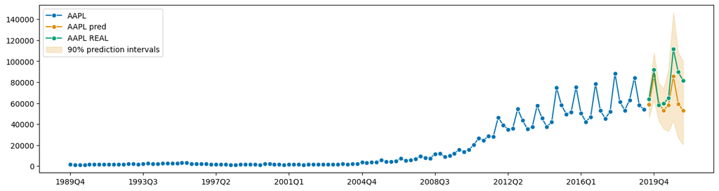

```python
fig, ax = plot_series(df_AAPL_train, AAPL_pred, df_AAPL_test, labels=["AAPL", "AAPL pred", "AAPL REAL"])
ax.fill_between(
    ax.get_lines()[-2].get_xdata(),
    AAPL_pred_ints[('Coverage', 0.9, 'lower')],
    AAPL_pred_ints[('Coverage', 0.9, 'upper')],
    alpha=0.2,
    color=ax.get_lines()[-2].get_c(),
    label=f"90% prediction intervals",
)
ax.legend(loc='upper left')
```

### Ampliación de la representación de realiadad, predicción e intervalos

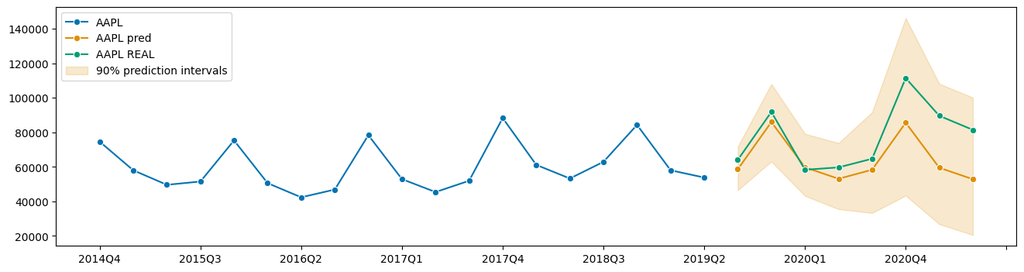

```python
fig, ax = plot_series(df_AAPL_train[100:], AAPL_pred, df_AAPL_test, labels=["AAPL", "AAPL pred", "AAPL REAL"])
ax.fill_between(
    ax.get_lines()[-2].get_xdata(),
    AAPL_pred_ints[('Coverage', 0.9, 'lower')],
    AAPL_pred_ints[('Coverage', 0.9, 'upper')],
    alpha=0.2,
    color=ax.get_lines()[-2].get_c(),
    label=f"90% prediction intervals",
)
ax.legend(loc='upper left');
```

## Cálculo de precisón del modelo ETS (MAM)

```python
mean_absolute_percentage_error(df_AAPL_test, AAPL_pred[0:8])
```

```
0.16273952063971214
```

```python
mse = MeanSquaredError()
mse(df_AAPL_test, AAPL_pred[0:8])
```

```
317747087.5426812
```

```python
rmse = MeanSquaredError(square_root=True)
rmse(df_AAPL_test, AAPL_pred[0:8])
```

```
17825.461776421984
```

### Modelo ETS => Tendencia Multiplicativa, error aditivo

```python
fh = np.arange(1, 9)
```

```python
apple_ets_AMM = AutoETS(auto=False, trend='mul', damped_trend=False,
                          seasonal='mul', error='add', sp=4, n_jobs=-1)
```

```python
apple_ets_AMM.fit(df_AAPL_train)
```

```
AutoETS(n_jobs=-1, seasonal='mul', sp=4, trend='mul')
```

```python
print(apple_ets_AMM._fitted_forecaster.summary())
```

```
                                 ETS Results
==============================================================================
Dep. Variable:                      y   No. Observations:                  119
Model:                       ETS(AMM)   Log Likelihood               -1125.900
Date:                Mon, 07 Nov 2022   AIC                           2271.801
Time:                        13:51:44   BIC                           2299.592
Sample:                    12-31-1989   HQIC                          2283.086
                         - 06-30-2019   Scale                      9672682.345
Covariance Type:               approx
======================================================================================
                         coef    std err          z      P>|z|      [0.025      0.975]
--------------------------------------------------------------------------------------
smoothing_level        0.7379      0.091      8.085      0.000       0.559       0.917
smoothing_trend        0.5574      0.101      5.518      0.000       0.359       0.755
smoothing_seasonal     0.2620      0.022     11.939      0.000       0.219       0.305
initial_level       1370.9326   2492.231      0.550      0.582   -3513.750    6255.615
initial_trend          0.9752      1.807      0.540      0.589      -2.567       4.517
initial_seasonal.0     0.5953      1.136      0.524      0.600      -1.630       2.821
initial_seasonal.1     0.9762      1.883      0.518      0.604      -2.715       4.668
initial_seasonal.2     1.1475      2.112      0.543      0.587      -2.991       5.286
initial_seasonal.3     1.0000      2.093      0.478      0.633      -3.102       5.102
===================================================================================
Ljung-Box (Q):                       20.32   Jarque-Bera (JB):               548.38
Prob(Q):                              0.01   Prob(JB):                         0.00
Heteroskedasticity (H):             126.00   Skew:                            -1.60
Prob(H) (two-sided):                  0.00   Kurtosis:                        13.02
===================================================================================

Warnings:
[1] Covariance matrix calculated using numerical (complex-step) differentiation.
```

```python
apple_pred_AMM2 = apple_ets_AMM.predict(fh)
apple_pred_AMM2
```

```
2019Q3     59802.351640
2019Q4     90080.512820
2020Q1     66099.079460
2020Q2     60022.067356
2020Q3     66707.639552
2020Q4    100481.974623
2021Q1     73731.441096
2021Q2     66952.725513
Freq: Q-DEC, dtype: float64
```

```
(<Figure size 1600x400 with 1 Axes>, <AxesSubplot: >)
```

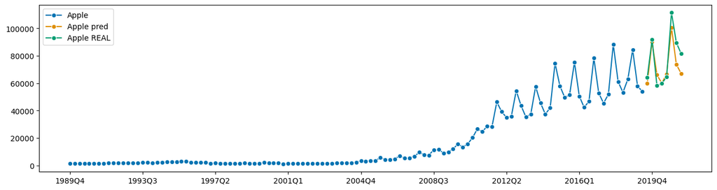

```python
plot_series(df_AAPL_train, apple_pred_AMM2, df_AAPL_test, labels=["Apple", "Apple pred", "Apple REAL"])
```

## Precisión del modelo

```python
mean_absolute_percentage_error(df_AAPL_test, apple_pred_AMM2)
```

```
0.08855576764263542
```

```python
mape_ets = MeanSquaredError()
mape_ets(df_AAPL_test, apple_pred_AMM2)
```

```
83352829.98653692
```

```python
rmse2 = MeanSquaredError(square_root=True)
rmse2(df_AAPL_test, apple_pred_AMM2)
```

```
9129.777104975616
```

# MODELO ARIMA

```python
df_AAPL = df_AAPL['Ingresos'].astype('float64').sort_index()
df_AAPL.tail()
```

```
2020Q2     59685.0
2020Q3     64698.0
2020Q4    111439.0
2021Q1     89584.0
2021Q2     81434.0
Freq: Q-DEC, dtype: float64
```

```
(<Figure size 1200x800 with 3 Axes>,
 array([<AxesSubplot: >,
        <AxesSubplot: title={'center': 'Autocorrelation'}>,
        <AxesSubplot: title={'center': 'Partial Autocorrelation'}>],
       dtype=object))
```

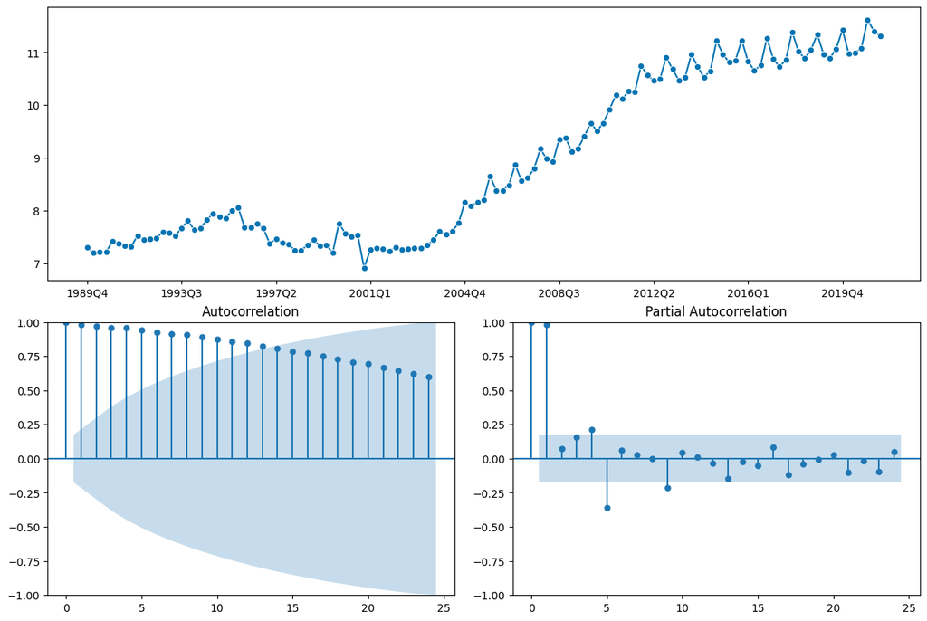

```python
# Autocorrelation Fuction Original Time Series
plot_correlations(log_AAPL)
```

## Predicción modelo ARIMA

### Separación entre train y test del dataset logaritmo

```
(<Figure size 1600x400 with 1 Axes>, <AxesSubplot: >)
```

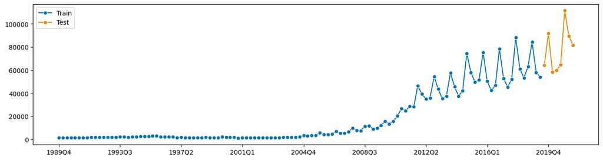

```python
df_AAPL_train , df_AAPL_test = temporal_train_test_split(y =df_AAPL, test_size=8)
log_AAPL_train, log_AAPL_test = temporal_train_test_split(y =log_AAPL, test_size=8)
plot_series(df_AAPL_train , df_AAPL_test, labels=["Train", "Test"])
```

```python
# longitud del la predicción
fh = np.arange(len(df_AAPL_test)) + 1
```

## Auto ARIMA Model

```python
forecaster = AutoARIMA(sp=4,suppress_warnings=True)
forecaster.fit(log_AAPL_train)
```

```
AutoARIMA(sp=4, suppress_warnings=True)
```

```python
#  Auto ARIMA Model Summary
print(forecaster.summary())
```

```
                                     SARIMAX Results
=========================================================================================
Dep. Variable:                                 y   No. Observations:                  119
Model:             SARIMAX(0, 1, 1)x(1, 0, 1, 4)   Log Likelihood                  58.362
Date:                           Mon, 07 Nov 2022   AIC                           -108.724
Time:                                   13:52:02   BIC                            -97.642
Sample:                               12-31-1989   HQIC                          -104.224
                                    - 06-30-2019
Covariance Type:                             opg
==============================================================================
                 coef    std err          z      P>|z|      [0.025      0.975]
------------------------------------------------------------------------------
ma.L1         -0.3363      0.089     -3.795      0.000      -0.510      -0.163
ar.S.L4        0.9156      0.062     14.822      0.000       0.795       1.037
ma.S.L4       -0.4810      0.106     -4.547      0.000      -0.688      -0.274
sigma2         0.0211      0.002     12.465      0.000       0.018       0.024
===================================================================================
Ljung-Box (L1) (Q):                   0.00   Jarque-Bera (JB):               552.06
Prob(Q):                              0.98   Prob(JB):                         0.00
Heteroskedasticity (H):               1.49   Skew:                            -1.49
Prob(H) (two-sided):                  0.22   Kurtosis:                        13.17
===================================================================================

Warnings:
[1] Covariance matrix calculated using the outer product of gradients (complex-step).
```

```python
#  Auto ARIMA Forecast
log_AAPL_pred = forecaster.predict(fh)
log_AAPL_pred
```

|  | Ingresos |
| --- | --- |
| 2019Q3 | 11.005156 |
| 2019Q4 | 11.335682 |
| 2020Q1 | 11.027217 |
| 2020Q2 | 10.934801 |
| 2020Q3 | 11.039461 |
| 2020Q4 | 11.342082 |
| 2021Q1 | 11.059660 |
| 2021Q2 | 10.975046 |

```python
#  Auto ARIMA Forecast
# Transformación inversa logarítmica
np.exp(log_AAPL_pred)
```

|  | Ingresos |
| --- | --- |
| 2019Q3 | 60183.650425 |
| 2019Q4 | 83757.569838 |
| 2020Q1 | 61526.133758 |
| 2020Q2 | 56094.940164 |
| 2020Q3 | 62284.081752 |
| 2020Q4 | 84295.340438 |
| 2021Q1 | 63554.933269 |
| 2021Q2 | 58398.523250 |

## Precisión del modelo ARIMA

```python
mean_absolute_percentage_error(log_AAPL_test, log_AAPL_pred)
```

```
0.01389307888873753
```

```python
mape_arima = MeanSquaredError(square_root=True)
mape_arima(log_AAPL_test, log_AAPL_pred)
```

```
0.20211115632064067
```

```python
rmse = MeanSquaredError(square_root=True)
rmse(df_AAPL_test, np.exp(log_AAPL_pred))
```

```
16022.724511396367
```

```
(<Figure size 1600x400 with 1 Axes>, <AxesSubplot: >)
```

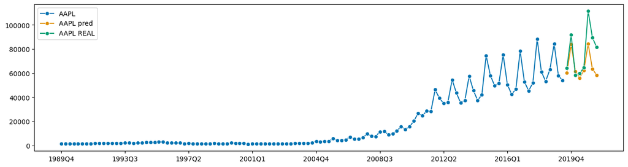

```python
# Forecast Accuracy Plot
# Plotting predictions and past data
plot_series(df_AAPL_train , np.exp(log_AAPL_pred),df_AAPL_test, labels=["AAPL", "AAPL pred", "AAPL REAL"])
```

```
(<Figure size 1600x400 with 1 Axes>, <AxesSubplot: >)
```

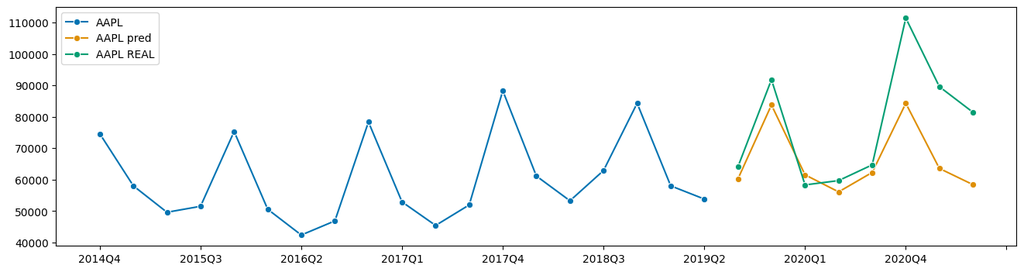

```python
plot_series(df_AAPL_train[100:], np.exp(log_AAPL_pred),df_AAPL_test, labels=["AAPL", "AAPL pred", "AAPL REAL"])
```

## Prediccion del modelo ETS-AMM

```python
fh = np.arange(9,15)
```

```python
apple_ets_AMM = AutoETS(auto=False, trend='mul', damped_trend=False,
                          seasonal='mul', error='add', sp=4, n_jobs=-1)
```

```python
apple_ets_AMM.fit(df_AAPL_train)
```

```
AutoETS(n_jobs=-1, seasonal='mul', sp=4, trend='mul')
```

```python
print(apple_ets_AMM._fitted_forecaster.summary())
```

```
                                 ETS Results
==============================================================================
Dep. Variable:                      y   No. Observations:                  119
Model:                       ETS(AMM)   Log Likelihood               -1125.900
Date:                Mon, 07 Nov 2022   AIC                           2271.801
Time:                        13:52:04   BIC                           2299.592
Sample:                    12-31-1989   HQIC                          2283.086
                         - 06-30-2019   Scale                      9672682.345
Covariance Type:               approx
======================================================================================
                         coef    std err          z      P>|z|      [0.025      0.975]
--------------------------------------------------------------------------------------
smoothing_level        0.7379      0.091      8.085      0.000       0.559       0.917
smoothing_trend        0.5574      0.101      5.518      0.000       0.359       0.755
smoothing_seasonal     0.2620      0.022     11.939      0.000       0.219       0.305
initial_level       1370.9326   2492.231      0.550      0.582   -3513.750    6255.615
initial_trend          0.9752      1.807      0.540      0.589      -2.567       4.517
initial_seasonal.0     0.5953      1.136      0.524      0.600      -1.630       2.821
initial_seasonal.1     0.9762      1.883      0.518      0.604      -2.715       4.668
initial_seasonal.2     1.1475      2.112      0.543      0.587      -2.991       5.286
initial_seasonal.3     1.0000      2.093      0.478      0.633      -3.102       5.102
===================================================================================
Ljung-Box (Q):                       20.32   Jarque-Bera (JB):               548.38
Prob(Q):                              0.01   Prob(JB):                         0.00
Heteroskedasticity (H):             126.00   Skew:                            -1.60
Prob(H) (two-sided):                  0.00   Kurtosis:                        13.02
===================================================================================

Warnings:
[1] Covariance matrix calculated using numerical (complex-step) differentiation.
```

### Predicción para año 2021 y 2022

```python
apple_pred_AMM3 = apple_ets_AMM.predict(fh)
apple_pred_AMM3
```

```
2021Q3     74410.270709
2021Q4    112084.477630
2022Q1     82245.100090
2022Q2     74683.656379
2022Q3     83002.313141
2022Q4    125026.704269
Freq: Q-DEC, dtype: float64
```

## Preguntas a Resolver

1- ¿Los ingresos de Apple son estacionarios? ¿En media? ¿En varianza?

2- ¿Cuál es su tendencia? ¿y su componente estacional?

3- ¿Cuales son las ventas anuales de Apple?

4- ¿Cuales son los crecimientos anuales de los ingresos?

5- ¿Qué modelo predice mejor?

6- ¿Existe efecto COVID? Cuantificar.

7- ¿Cuales son las ventas acumuladas para el año 2021? ¿Y para el 2022?

8- ¿Son creíbles las predicciones del Barclays?

3- ¿Cuales son las ventas anuales de Apple?

```python
df_AAPL = (pd.read_csv("/Users/eduardo/Documents/CUNEF_ASIGNATURAS/SERIES_TEMPORALES/Trabajo_HW/data/raw/aapl_ok.csv",sep=';')
           .assign(**{'fecha': lambda df: pd.to_datetime(df['fecha'])})
           .assign(**{'Ingresos': lambda df: df['Ingresos'].str.replace(',', '.').astype(float)}))
```

```python
separar_fecha = df_AAPL['fecha'].dt.year
col_ingresos = df_AAPL['Ingresos']
tot_col = pd.concat([separar_fecha,col_ingresos],axis = 1)
DF_TOTAL=tot_col.groupby(['fecha'], sort=True)['Ingresos'].sum()
df_ingXaño = pd.DataFrame(DF_TOTAL)
df_ingXaño.tail()
```

| fecha | Ingresos |
| --- | --- |
| 2017 | 238536.0 |
| 2018 | 261612.0 |
| 2019 | 267683.0 |
| 2020 | 294135.0 |
| 2021 | 171018.0 |

El año 2021 tiene induce a error puesto que los datos del año 2021 no estan completos, por lo tanto no podemos tomarlo como un indicador fiable para ver los ingresos totales del año o su tasa de crecimiento

4- ¿Cuales son los crecimientos anuales de los ingresos?

```python
df_ingXaño['Crecimiento']=df_ingXaño['Ingresos']
df_ingXaño.iloc[0,1] = np.nan
df_ingXaño
df_ingXaño.iloc[1:,1] = df_ingXaño.iloc[1:,0].values / df_ingXaño.iloc[:-1,0].values
df_crecXaño = round(df_ingXaño['Crecimiento'],2)
pd.DataFrame(df_crecXaño).tail()
```

| fecha | Crecimiento |
| --- | --- |
| 2017 | 1.09 |
| 2018 | 1.10 |
| 2019 | 1.02 |
| 2020 | 1.10 |
| 2021 | 0.58 |

5- ¿Qué modelo predice mejor?

El modelo que mejor predice es el ETS - AMM, y ahora procedemos a calcular su predicción para los siguientes cuatrimestres, puesto que es el que menor rsme y mape

6- ¿Existe efecto COVID? Cuantificar.

```python
df_AAPL['Trimeste'] = pd.PeriodIndex(df_AAPL.fecha, freq='Q')
df_AAPL = df_AAPL.set_index('Trimeste')

#creamos un nuevo data frame con los trimestres como indices e ingresos como datos, por tanto eliminamos la fehca
df_AAPL= df_AAPL.drop('fecha', axis=1)
df_AAPL.head()
```

| Trimeste | Ingresos |
| --- | --- |
| 1989Q4 | 1493.4 |
| 1990Q1 | 1346.2 |
| 1990Q2 | 1364.8 |
| 1990Q3 | 1354.1 |
| 1990Q4 | 1675.5 |

| Trimeste | Ingresos | Ingresos_prediccion | Efecto_covid, predicción vs realidad |
| --- | --- | --- | --- |
| 2020Q1 | 58313.0 | 66099.079460 | 0.882206 |
| 2020Q2 | 59685.0 | 60022.067356 | 0.994384 |
| 2020Q3 | 64698.0 | 66707.639552 | 0.969874 |
| 2020Q4 | 111439.0 | 100481.974623 | 1.109045 |
| 2021Q1 | 89584.0 | 73731.441096 | 1.215004 |
| 2021Q2 | 81434.0 | 66952.725513 | 1.216291 |

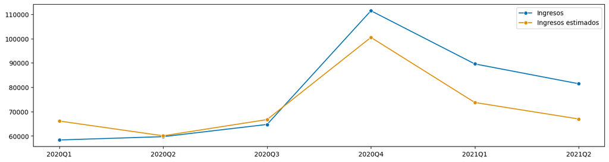

```python
apple_covid = df_AAPL.loc['2020-03-31':]
apple_covid["Ingresos_prediccion"] = apple_pred_AMM2[2:9]
apple_covid["Efecto_covid, predicción vs realidad"] = apple_covid["Ingresos"] / apple_covid["Ingresos_prediccion"]
apple_covid2 = df_AAPL.loc['2020-03-31':]
Ingresos_estimados = apple_pred_AMM2[2:9]
plot_series(apple_covid2,Ingresos_estimados,labels=["Ingresos", "Ingresos estimados"])
apple_covid
```

Hemos calculado los porcentajes segun nuestras estimaciones con el AMM y vemos que al inicio del covid-19 impacto de una forma considerable según la prediccón aunque se recupero rápido. En la gráfica podemos observar que a partir de tercer trimestre de 2020 los ingresos de apple se disparan.

7- ¿Cuales son las ventas acumuladas para el año 2021? ¿Y para el 2022?

```python
apple_2021_2022 = pd.DataFrame(apple_pred_AMM3).reset_index()
apple_2021_2022.columns = ['fecha','Ingresos']
apple_2021_2022['fecha'] = apple_2021_2022['fecha'].astype(str).str[:4]
apple_2021_2022['fecha'] = apple_2021_2022['fecha'].astype(str)
año_2021 = pd.DataFrame(DF_TOTAL[-1:])
apple6 = pd.merge(año_2021,apple_2021_2022,how ="outer")
si = apple6["Ingresos"]
acumulado_2021 =sum(si[0:3])
print(round(acumulado_2021,2))
acumulado_2022 = sum(si[3:7])
round(acumulado_2022,2)
```

```
357512.75
```

```
364957.77
```

En 2021 los ingresos acumulados son 357512.75 mientras que en 2022 los ingresos acumulados son 364957.77